# Predicting donors

Hemal Agarwal

October 21, 2016

```r
setwd("C:/Users/Adroit/Desktop/files_dssap")
data_outcomes <- read.csv("outcomes.csv")
data_projects<- read.csv("projects.csv")
#data_resources <- read.csv("resources.csv")
#data_essays <-read.csv("essays.csv")
data_donations <- read.csv("donations.csv")
#data_submissions <- read.csv("sampleSubmissions.csv")
```

# 1.Understanding the proportions of projects that have been fully funded

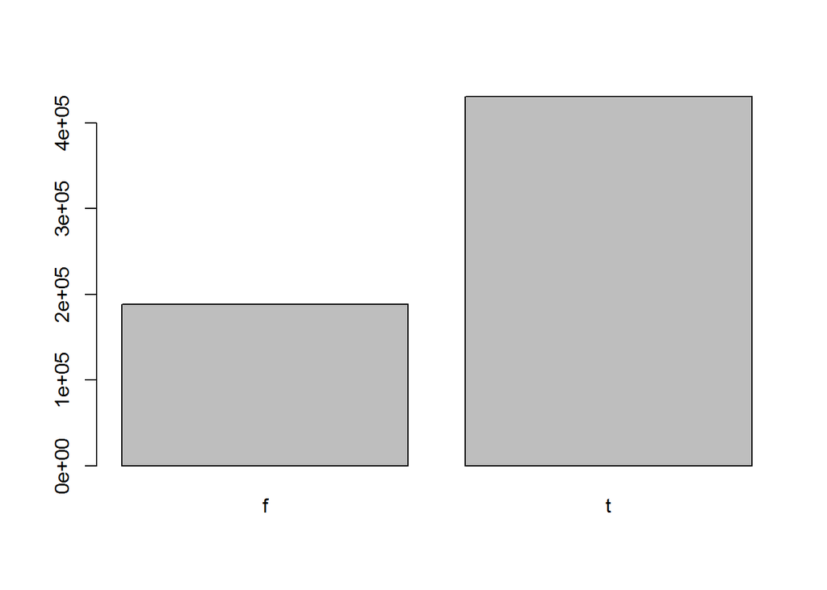

```r
data_fullyFunded = data_outcomes$fully_funded
data_fullyFunded_table = (table(data_fullyFunded))
data_fullyFunded_freq <- as.data.frame((table(data_fullyFunded)))
#data_fullyFunded
#     f      t
#188643 430683
barplot(data_fullyFunded_table)
```

```r
as.data.frame(table(data_fullyFunded))
```

```
##   data_fullyFunded   Freq
## 1                f 188643
## 2                t 430683
```

```r
# x   freq
#1 f 188643
#2 t 430683

prop_fullyfunded = (data_fullyFunded_freq$Freq[data_fullyFunded_freq$data_fullyFunded == "t"])/length(data_fullyFunded)
#0.695406
```

Analysis About 70% of the projects have been fully funded

# 2.Understanding the proportion of Exciting projets

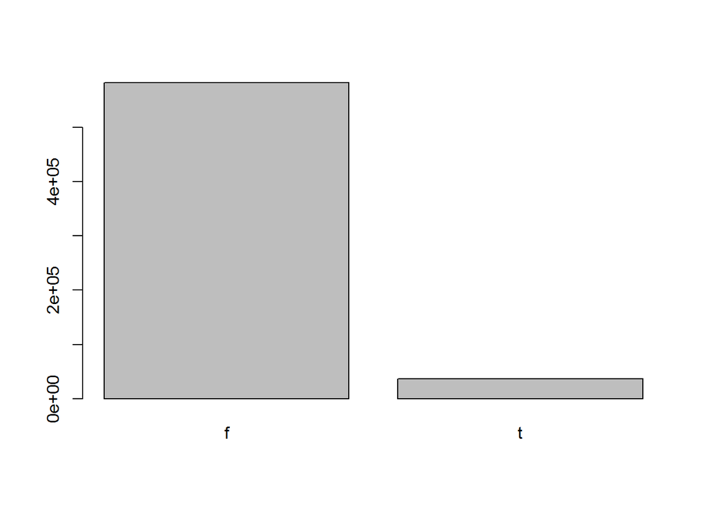

```r
data_excitingProjects = data_outcomes$is_exciting
data_excitingProjects.freq = as.data.frame(table(data_excitingProjects))
# data_excitingProjects   Freq
#1                     f 582616
#2                     t  36710
barplot(table(data_excitingProjects))
```

```r
#proportion of exciting projects
prop_exciting<- data_excitingProjects.freq$Freq[(data_excitingProjects.freq$data_excitingProjects=="t")]/ length(data_outcomes$is_exciting)
prop_exciting
```

```
## [1] 0.05927411
```

```r
 #0.05927411
```

# 3.Examinining the factors which form criteria for an exciting projects

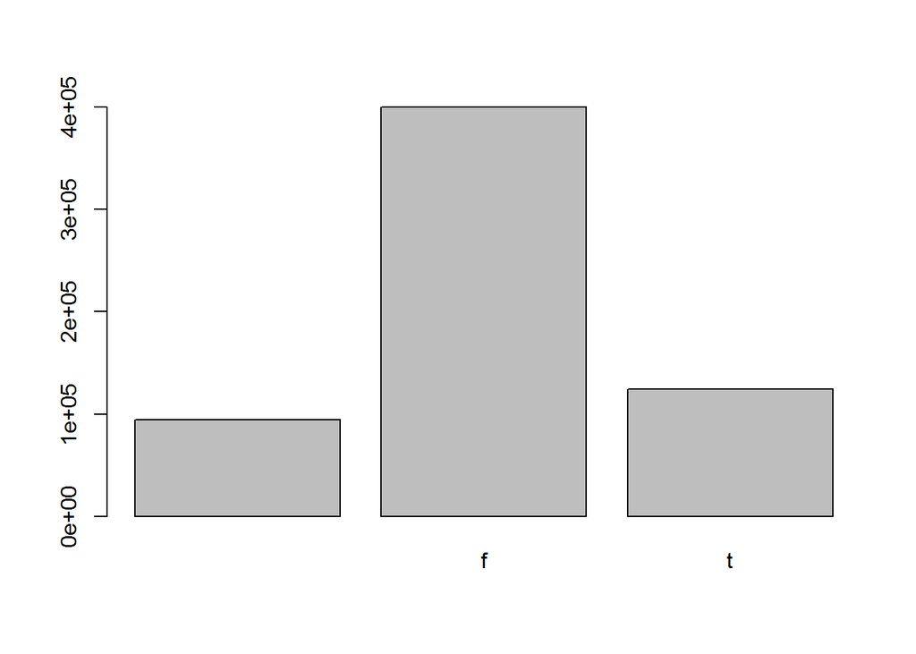

```r
# the number of projects that had atleast one teacher referred donor

data_atLeastOneTeacherDonor <- data_outcomes$at_least_1_teacher_referred_donor
data_atLeastOneTeacherDonor.freq <- as.data.frame(table(data_atLeastOneTeacherDonor))
# data_atLeastOneTeacherDonor   Freq
#1                         NA   94398
#2                           f 400268
#3                           t 124660

barplot(table(data_atLeastOneTeacherDonor))
```

```r
#proportion of projects that had atleast one teacher referred donor
a<-data_atLeastOneTeacherDonor.freq$Freq[data_atLeastOneTeacherDonor.freq$data_atLeastOneTeacherDonor=="t"]
b<-data_atLeastOneTeacherDonor.freq$Freq[data_atLeastOneTeacherDonor.freq$data_atLeastOneTeacherDonor=="f"]
prop<- a/(a+b)
prop
```

```
## [1] 0.2374802
```

```r
# 0.2374802
```

Analysis:about 23% of the total projects(ignoring the projects for which the information is not available), are atleast one teacher referred donor

# 4.Projects with atleast one Green donation

```r
data_atLeastOneGreenDonation <- data_outcomes$at_least_1_green_donation
data_atLeastOneGreenDonation.freq <- as.data.frame(table(data_atLeastOneGreenDonation))
#  data_atLeastOneGreenDonation   Freq
#1                               94398
#2                            f 146235
#3                            t 378693

a<- data_atLeastOneGreenDonation.freq$Freq[data_atLeastOneGreenDonation.freq$data_atLeastOneGreenDonation== "t"]
b<- data_atLeastOneGreenDonation.freq$Freq[data_atLeastOneGreenDonation.freq$data_atLeastOneGreenDonation== "f"]
prop<-a/(a+b)
prop
```

```
## [1] 0.7214189
```

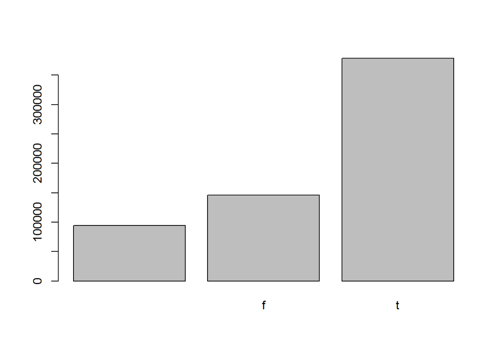

```r
#[1] 0.7214189
barplot(table(data_atLeastOneGreenDonation))
```

About 72% of the projects have atleast one donor who pays via credit card/giftcard

# 5Are schools with higher poverty levels likely to get funded any more than schools with lower poverty levels.

```r
#analysing by poverty level
Df_outcomeProjects <- merge(data_projects, data_outcomes, by.x="projectid", by.y="projectid", all.x=T)

Df_outcomeProjects$poverty<- 0
Df_outcomeProjects$poverty[Df_outcomeProjects$poverty_level=="moderate poverty"] <- 1
Df_outcomeProjects$poverty[Df_outcomeProjects$poverty_level=="high poverty"] <- 2
Df_outcomeProjects$poverty[Df_outcomeProjects$poverty_level=="highest poverty"] <- 3

poverty_stats<- as.data.frame(table(Df_outcomeProjects$poverty))
# Var1   Freq
#1    0  16711
#2    1  90337
#3    2 173561
#4    3 383489
poverty_stats_funded<- as.data.frame(table((Df_outcomeProjects$poverty[Df_outcomeProjects$fully_funded == "t"])))
poverty_stats <- merge(poverty_stats,poverty_stats_funded,by.x = "Var1",by.y = "Var1",all.x = TRUE)


poverty_stats["proportion"] <- (poverty_stats$Freq.y)/(poverty_stats$Freq.x)
poverty_stats
```

```
##   Var1 Freq.x Freq.y proportion
## 1    0  16711  10219  0.6115134
## 2    1  90337  53613  0.5934778
## 3    2 173561 106581  0.6140838
## 4    3 383489 260270  0.6786896
```

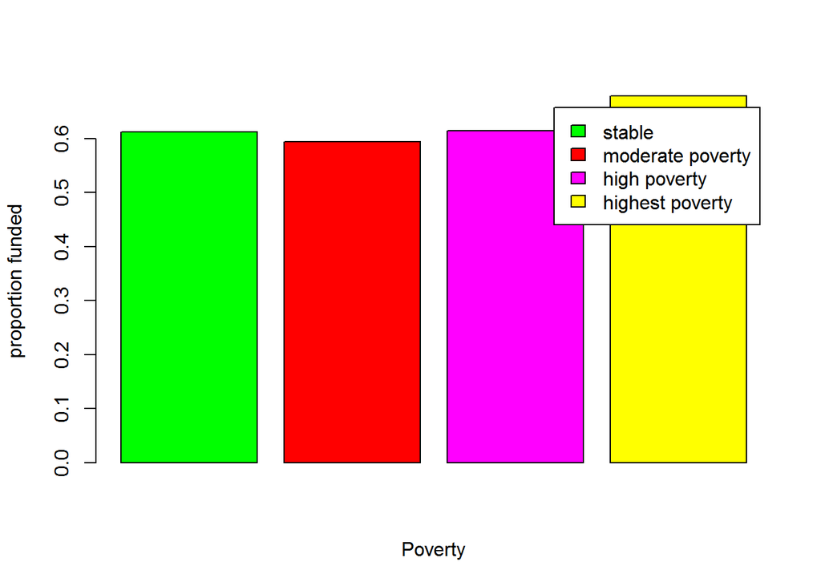

```r
barplot(poverty_stats$proportion, legend.text = c("stable","moderate poverty","high poverty","highest poverty"),col = c("green","red","magenta","yellow"),xlab = "Poverty",ylab = "proportion funded")
```

Analysis: Maximum number of projects are posted by schools with highest poverty levels. While greater proportion of projects from schools with highest poverty level are funded, however, it difference is not too significant. The povertly level of the school does not seem to matter all the much on the funding aspect of the project.This is a matter of concern. The next question to be asked is if donors look at the schools poverty while making a donation?

# SECTION2 : DATA STORY

# Are projects likely to get fully funded based on the type of location ?

Analysing by the type of location

```r
levels(Df_outcomeProjects$school_metro)
```

```
## [1] ""         "rural"    "suburban" "urban"
```

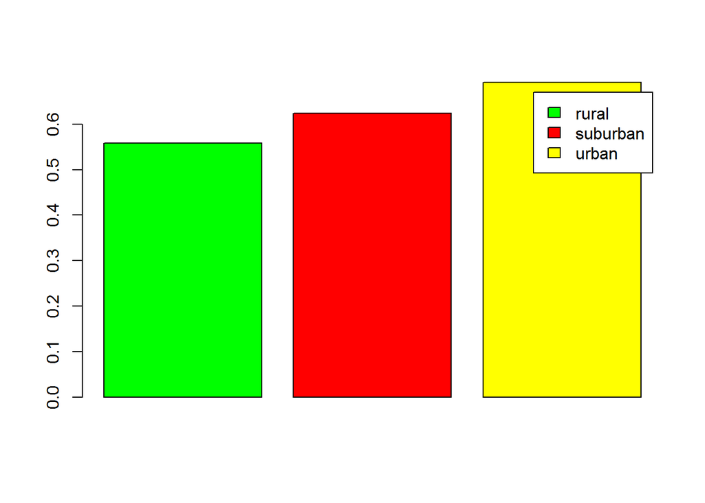

```r
Df_outcomeProjects$Metro_type<- 0
Df_outcomeProjects$Metro_type[Df_outcomeProjects$school_metro== "rural"] <- 1
Df_outcomeProjects$Grade[Df_outcomeProjects$school_metro== "suburban"] <- 2
Df_outcomeProjects$Grade[Df_outcomeProjects$school_metro== "urban"] <- 3

Metro_stat <- as.data.frame(table(Df_outcomeProjects$school_metro))
Metro_stats_funded <- as.data.frame(table((Df_outcomeProjects$school_metro[Df_outcomeProjects$fully_funded == "t"])))
Metro_stats <- merge(Metro_stat, Metro_stats_funded ,by.x = "Var1",by.y = "Var1",all.x = TRUE)
Metro_stats["prop"] = Metro_stats$Freq.y/Metro_stats$Freq.x
barplot((Metro_stats$prop[2:4]),legend.text= c("rural","suburban","urban"),col = c("green","red","yellow"))
```

Greater proportion of projects in urban areas are fully funded as compared to rural areas.

# Does the location of the school really matter to the donors?

```r
levels(data_projects$school_state)
```

```
##  [1] "AK" "AL" "AR" "AZ" "CA" "CO" "CT" "DC" "DE" "FL" "GA" "HI" "IA" "ID"
## [15] "IL" "IN" "KS" "KY" "La" "LA" "MA" "MD" "ME" "MI" "MN" "MO" "MS" "MT"
## [29] "NC" "ND" "NE" "NH" "NJ" "NM" "NV" "NY" "OH" "OK" "OR" "PA" "RI" "SC"
## [43] "SD" "TN" "TX" "UT" "VA" "VT" "WA" "WI" "WV" "WY"
```

```r
states<- c(levels(data_projects$school_state))
states
```

```
##  [1] "AK" "AL" "AR" "AZ" "CA" "CO" "CT" "DC" "DE" "FL" "GA" "HI" "IA" "ID"
## [15] "IL" "IN" "KS" "KY" "La" "LA" "MA" "MD" "ME" "MI" "MN" "MO" "MS" "MT"
## [29] "NC" "ND" "NE" "NH" "NJ" "NM" "NV" "NY" "OH" "OK" "OR" "PA" "RI" "SC"
## [43] "SD" "TN" "TX" "UT" "VA" "VT" "WA" "WI" "WV" "WY"
```

```r
data_states_totalprojects = data_projects$school_sta
data_states_totalprojects_freq = table(data_states_totalprojects)
data_states_totalprojects_freq = as.data.frame(table(data_states_totalprojects))
data_states_totalprojects_freq
```

```
##    data_states_totalprojects   Freq
## 1                         AK   1383
## 2                         AL   5650
## 3                         AR   5770
## 4                         AZ   9837
## 5                         CA 126242
## 6                         CO   7021
## 7                         CT   7728
## 8                         DC   6918
## 9                         DE   1605
## 10                        FL  30605
## 11                        GA  15403
## 12                        HI   2586
## 13                        IA   3186
## 14                        ID   2030
```

[output cut: 38 more lines]

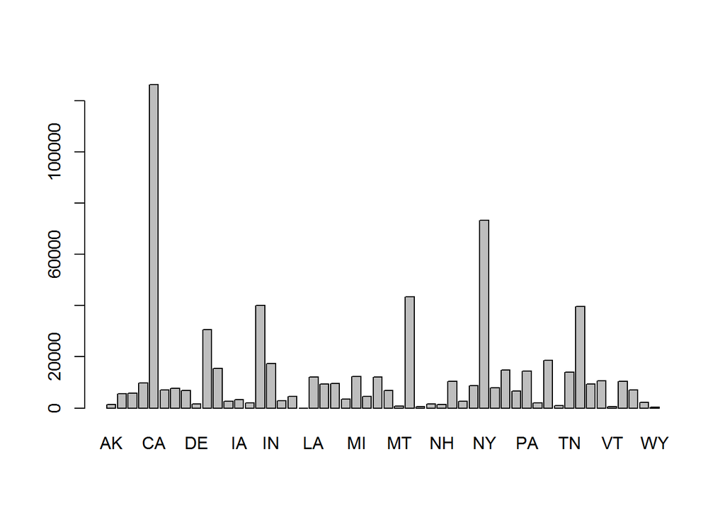

```r
barplot(table(data_states_totalprojects))
```

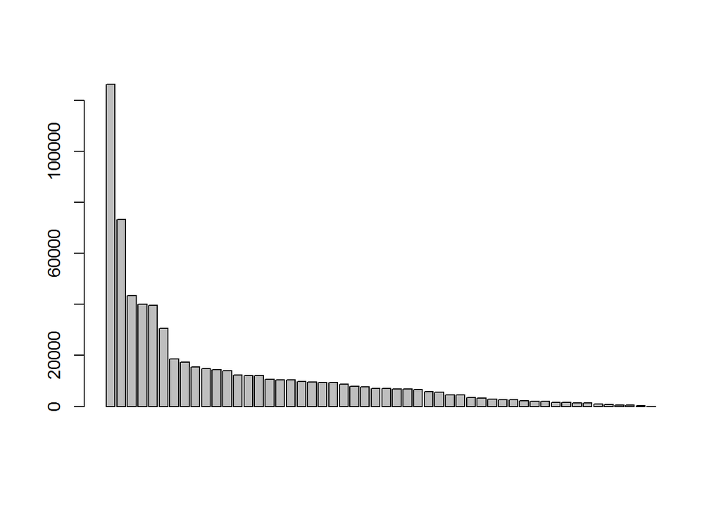

```r
project.state.orders<- data_states_totalprojects_freq[rev(order(data_states_totalprojects_freq$Freq)),]

barplot(project.state.orders$Freq)
```

```r
sum(as.numeric(project.state.orders$Freq[1:10]))/sum(as.numeric(project.state.orders$Freq))
```

```
## [1] 0.6316914
```

```r
#0.6316914
sum(as.numeric(project.state.orders$Freq[1:5]))/sum(as.numeric(project.state.orders$Freq))
```

```
## [1] 0.4859674
```

```r
#0.4859674
sum(as.numeric(project.state.orders$Freq[1]))/sum(as.numeric(project.state.orders$Freq))
```

```
## [1] 0.1900954
```

```r
#0.1900954
```

Analysis: Most of the projects come from specific states. Infact 48% of the total projects are posted from 5 states of the 52 :CA, NY, NC,IL, TX, and 19% come from CA alone.

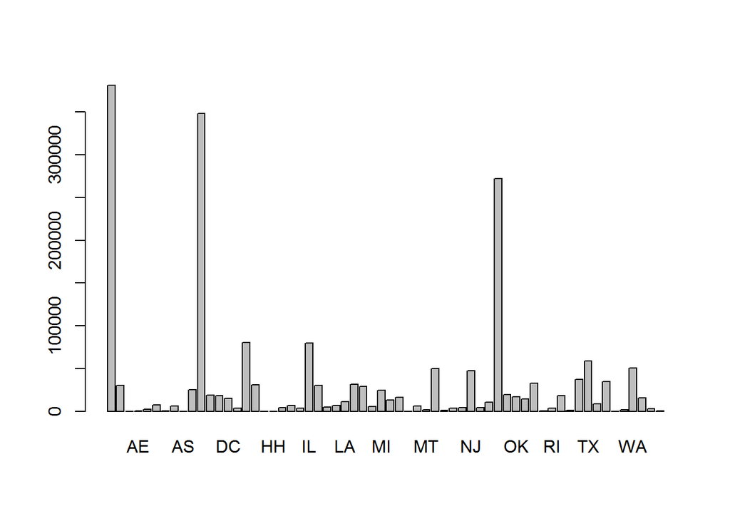

```r
#Merging dataframes
Df_outcomeProjects <- merge(data_projects, data_outcomes, by.x="projectid", by.y="projectid", all.x=T)



#analysing which states make maximi=um donation transactions
data_state_donations <- data_donations$donor_state
data_state_donations.freq <- as.data.frame(table(data_state_donations))
barplot(table(data_state_donations))
```

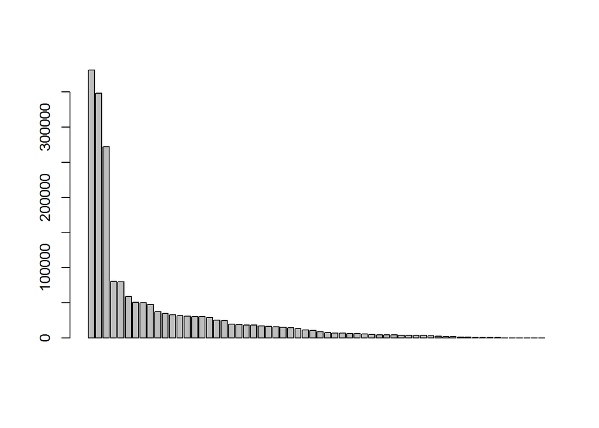

```r
data_state_donations.freq_order<- data_state_donations.freq[rev(order(data_state_donations.freq$Freq)),]
barplot(data_state_donations.freq_order$Freq)
```

```r
sum(as.numeric(data_state_donations.freq_order$Freq[2:11]))/sum(as.numeric(data_state_donations.freq_order$Freq[2:61]))
```

```
## [1] 0.6732629
```

```r
#0.6732629
sum(as.numeric(data_state_donations.freq_order$Freq[2:6]))/sum(as.numeric(data_state_donations.freq_order$Freq[2:61]))
```

```
## [1] 0.5334914
```

```r
#0.5334914
sum(as.numeric(data_state_donations.freq_order$Freq[2]))/sum(as.numeric(data_state_donations.freq_order$Freq[2:61]))
```

```
## [1] 0.2214089
```

```r
#0.2214089
```

Analysis: About 53% of the donations (in terms of transcactions) come from 5 states. we also observe that ecept for FL, the states that make makinum number of donations are also the ones that post maximum number of projects. Question to answer: does it so happen that donors donate to schools that are located within their state ?

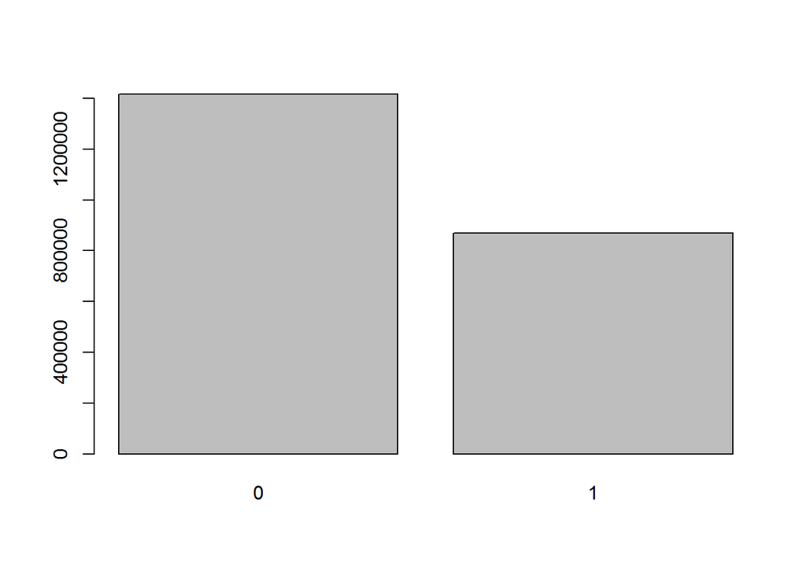

```r
Df_outcomes.projects.donations <- merge(Df_outcomeProjects,data_donations,by.x="projectid", by.y="projectid", all.x=T)

Df_outcomes.projects.donations$same.state <- 0
Df_outcomes.projects.donations$same.state[as.character(Df_outcomes.projects.donations$school_state)== as.character(Df_outcomes.projects.donations$donor_state)]<-1
data_matchstates<- as.data.frame(table(Df_outcomes.projects.donations$same.state))
# Var1    Freq
#1    0 1416875
#2    1  869490
donor_states_NA <- sum(data_state_donations.freq_order$Freq[1])

barplot(table(Df_outcomes.projects.donations$same.state))
```

```r
# examiniming the proportion of people who donated for projects of the schools from the same state(Ignoring the NA values )
as.numeric(data_matchstates$Freq[data_matchstates$Var1==1])/(as.numeric(data_matchstates$Freq[data_matchstates$Var1==0])+as.numeric(data_matchstates$Freq[data_matchstates$Var1==1])-donor_states_NA)
```

```
## [1] 0.4564197
```

```r
#0.4564197
```

# KeyInsight

46% of the donation transactions were made for projects from the same state as donors state. It seems like donors like to make donations to schools from their own state.

# Are some neighborhoods likely to make more donations than the other neighborhoods?

```r
zip_codes<- as.numeric(data_donations$donor_zip)
zip_codes.freq = as.data.frame(table(zip_codes) )
zp.orders<- zip_codes.freq[rev(order(zip_codes.freq$Freq)),]
head(zp.orders,100)
```

```
##       zip_codes  Freq
## 19250     94102 23523
## 20375     98102  7545
## 2246      10018  7454
## 2229      10001  7402
## 13751     62715  6809
## 1934       8091  6271
## 10294     46077  4897
## 15280     73104  4682
## 2274      10065  4569
## 1             0  3769
## 2251      10023  3647
## 13277     60631  3195
## 2245      10017  2919
## 2250      10022  2911
```

[output cut: 86 more lines]

```r
length(zp.orders$zip_codes)
```

```
## [1] 20822
```

```r
sum(as.numeric(zp.orders$Freq[1:100]))/sum(as.numeric(zp.orders$Freq[1:length(zp.orders$zip_codes)]))
```

```
## [1] 0.2326013
```

```r
# 0.2326013
100/length(zp.orders$zip_codes)
```

```
## [1] 0.004802613
```

```r
# 0.004802613
sum(as.numeric(zp.orders$Freq[1:50]))/sum(as.numeric(zp.orders$Freq[1:length(zp.orders$zip_codes)]))
```

```
## [1] 0.178028
```

```r
# 0.178028
```

# Key Insight

Some neighborhoods make a lot more donation transactions than the other neighborhoods.

The next question to be asked is if the total donation made by these zipcodes is a lot more than the other zipcodes.

# 2.Are peoply like to make more donations in certain months??

```r
mon.donation<-c()
mon.donation<-months( as.POSIXct(data_donations$donation_timestamp[1:length(data_donations$donation_timestamp)]))
mon.donation.freq <- as.data.frame(table(mon.donation))
order
```

[output not shown]

```r
mon.order <- mon.donation.freq[rev(order(mon.donation.freq$Freq)),]
mon.order
```

```
##    mon.donation   Freq
## 3      December 319931
## 11      October 242150
## 5       January 214295
## 8         March 193442
## 10     November 179655
## 12    September 178941
## 1         April 154668
## 4      February 128979
## 2        August 120740
## 9           May  83838
## 6          July  71008
## 7          June  65697
```

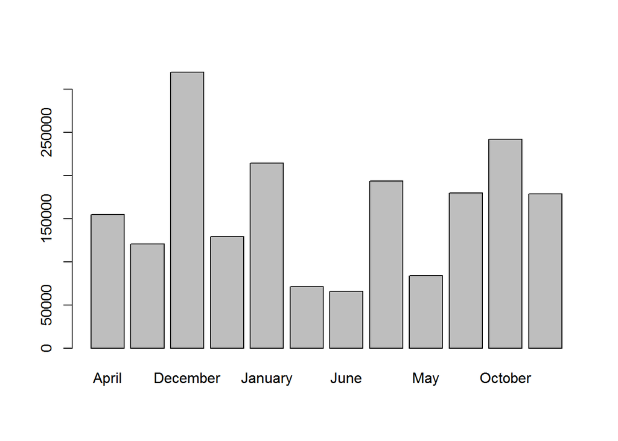

```r
barplot(table(mon.donation))
```

```r
sum(mon.order$Freq[1:3])/sum(mon.order$Freq[1:12])
```

```
## [1] 0.3974599
```

```r
#0.3974599
sum(mon.order$Freq[1])/sum(mon.order$Freq[1:12])
```

```
## [1] 0.1637863
```

```r
sum(mon.order$Freq[10:12])/sum(mon.order$Freq[1:12])
```

```
## [1] 0.1129054
```

# KeyInsight

Highest number of donation is made in December, which accounts to almost 17% of the total donation.

Maximum number of donations are made in 3 months of December,October and january which account to 40% of the total donation transactions.

These are also the festive months. while the least donations are transacted in the summer months of May, June and July accounting to only 11% of the toal transactions.

# PART3 : Some Questions to the partners

Q.What are the income levels of various neighbourhoods that form the donor audience for the site?

It may be interesting to understand how income levels effect the donations made to school projects.

Q. How is the audience made aware of this site? What mediums have been used by this website used for its own promotion?

Does the medium of promotion make an impact on the amount of donation for different projects?

Q.How does the company decide the order in which the projects are listed on the site?

Is it possible that projects that are published on the top of page get more funding than the rest?